```python
# Automatically reload imported modules that are changed outside this notebook
%load_ext autoreload
%autoreload 2

# More pixels in figures
import matplotlib.pyplot as plt
%matplotlib inline
plt.rcParams["figure.dpi"] = 200

# Init PRNG with fixed seed for reproducibility
import numpy as np
np_rng = np.random.default_rng(1)

import tensorflow as tf
tf.random.set_seed(np_rng.integers(0, tf.int64.max))
```

# Representation learning and back-end classification

**2020-11-21**

This example expands `common-voice-augmenting` by implementing language vector classification. So far, we have used the x-vector neural network as an end-to-end classifier, making classification decisions based on its log-softmax outputs. However, it can also be used for [representation learning](https://www.deeplearningbook.org/contents/representation.html) by adding a second step after training. Once we have found reasonably optimal weights for the network, we extract all speech data as fixed-length vectors and train a separate, back-end classifier on these vectors. These vectors are also called [embeddings](https://en.wikipedia.org/wiki/Embedding). As explained in the original [x-vector paper](http://danielpovey.com/files/2018_odyssey_xvector_lid.pdf), one benefit of this approach is that we could first train a single neural network on vast amounts of data in hundreds of languages, which can then be used as a feature extractor for producing training data to arbitrary back-end classifiers. These back-end classifiers could be trained on any subset of languages from the larger training set.

## Data

This example uses the same data as in the `common-voice-small` example.

```python
import urllib.parse
from IPython.display import display, Markdown


languages = """
    et
    mn
    ta
    tr
""".split()

languages = sorted(l.strip() for l in languages)

display(Markdown("### Languages"))
display(Markdown('\n'.join("* `{}`".format(l) for l in languages)))

bcp47_validator_url = 'https://schneegans.de/lv/?tags='
display(Markdown("See [this tool]({}) for a description of the BCP-47 language codes."
                 .format(bcp47_validator_url + urllib.parse.quote('\n'.join(languages)))))
```

Languages

- `et`

- `mn`

- `ta`

- `tr`

See [this tool](https://schneegans.de/lv/?tags=et%0Amn%0Ata%0Atr) for a description of the BCP-47 language codes.

## Loading and preparing the metadata

```python
import os
import pandas as pd
from lidbox.meta import (
    common_voice,
    generate_label2target,
    verify_integrity,
    read_audio_durations,
    random_oversampling_on_split
)


workdir = "/data/exp/cv4-embed"
datadir = "/mnt/data/speech/common-voice/downloads/2020/cv-corpus"

print("work dir:", workdir)
print("data source dir:", datadir)
print()

os.makedirs(workdir, exist_ok=True)
assert os.path.isdir(datadir), datadir + " does not exist"

dirs = sorted((f for f in os.scandir(datadir) if f.is_dir()), key=lambda f: f.name)

print(datadir)
for d in dirs:
    if d.name in languages:
        print(' ', d.name)
        for f in os.scandir(d):
            print('   ', f.name)

missing_languages = set(languages) - set(d.name for d in dirs)
assert missing_languages == set(), "missing languages: {}".format(missing_languages)

meta = common_voice.load_all(datadir, languages)
meta, lang2target = generate_label2target(meta)

print("\nsize of all metadata", meta.shape)
meta = meta.dropna()
print("after dropping NaN rows", meta.shape)

print("verifying integrity")
verify_integrity(meta)
print("ok\n")

print("reading audio durations")
meta["duration"] = read_audio_durations(meta)
print("balancing the label distributions")
meta = random_oversampling_on_split(meta, "train")
```

```
work dir: /data/exp/cv4-embed
data source dir: /mnt/data/speech/common-voice/downloads/2020/cv-corpus

/mnt/data/speech/common-voice/downloads/2020/cv-corpus
  et
    validated.tsv
    invalidated.tsv
    other.tsv
    dev.tsv
    train.tsv
    clips
    test.tsv
    reported.tsv
  mn
    validated.tsv
    invalidated.tsv
    other.tsv
    dev.tsv
    train.tsv
    clips
    test.tsv
    reported.tsv
  ta
    validated.tsv
    invalidated.tsv
    other.tsv
    dev.tsv
    train.tsv
    clips
    test.tsv
    reported.tsv
  tr
    validated.tsv
    invalidated.tsv
    other.tsv
    dev.tsv
    train.tsv
    clips
    test.tsv
    reported.tsv

size of all metadata (23842, 6)
after dropping NaN rows (23842, 6)
verifying integrity
ok

reading audio durations
balancing the label distributions
```

## Preparing the feature extraction pipeline

```python
from lidbox.features import audio, cmvn
import lidbox.data.steps as ds_steps
import scipy.signal


TF_AUTOTUNE = tf.data.experimental.AUTOTUNE


def metadata_to_dataset_input(meta):
    return {
        "id": tf.constant(meta.index, tf.string),
        "path": tf.constant(meta.path, tf.string),
        "label": tf.constant(meta.label, tf.string),
        "target": tf.constant(meta.target, tf.int32),
        "split": tf.constant(meta.split, tf.string),
        "is_copy": tf.constant(meta.is_copy, tf.bool),
    }


def read_mp3(x):
    s, r = audio.read_mp3(x["path"])
    out_rate = 16000
    s = audio.resample(s, r, out_rate)
    s = audio.peak_normalize(s, dBFS=-3.0)
    s = audio.remove_silence(s, out_rate)
    return dict(x, signal=s, sample_rate=out_rate)


def random_filter(x):
    def scipy_filter(s, N=10):
        b = np_rng.normal(0, 1, N)
        return scipy.signal.lfilter(b, 1.0, s).astype(np.float32), b
    s, _ = tf.numpy_function(
        scipy_filter,
        [x["signal"]],
        [tf.float32, tf.float64],
        name="np_random_filter")
    s = tf.cast(s, tf.float32)
    s = audio.peak_normalize(s, dBFS=-3.0)
    return dict(x, signal=s)


def random_speed_change(ds):
    return ds_steps.random_signal_speed_change(ds, min=0.9, max=1.1, flag="is_copy")


def batch_extract_features(x):
    with tf.device("GPU"):
        signals, rates = x["signal"], x["sample_rate"]
        S = audio.spectrograms(signals, rates[0])
        S = audio.linear_to_mel(S, rates[0])
        S = tf.math.log(S + 1e-6)
        S = cmvn(S, normalize_variance=False)
    return dict(x, logmelspec=S)


def pipeline_from_meta(data, split):
    if split == "train":
        data = data.sample(frac=1, random_state=np_rng.bit_generator)

    ds = (tf.data.Dataset
            .from_tensor_slices(metadata_to_dataset_input(data))
            .map(read_mp3, num_parallel_calls=TF_AUTOTUNE))

    if split == "test":
        return (ds
            .batch(1)
            .map(batch_extract_features, num_parallel_calls=TF_AUTOTUNE)
            .unbatch()
            .cache(os.path.join(cachedir, "data", split))
            .prefetch(1000))
    else:
        return (ds
            .cache(os.path.join(cachedir, "data", split))
            .prefetch(1000)
            .apply(random_speed_change)
            .map(random_filter, num_parallel_calls=TF_AUTOTUNE)
            .batch(1)
            .map(batch_extract_features, num_parallel_calls=TF_AUTOTUNE)
            .unbatch())


cachedir = os.path.join(workdir, "cache")
os.makedirs(os.path.join(cachedir, "data"))

split2ds = {split: pipeline_from_meta(meta[meta["split"]==split], split)
            for split in meta.split.unique()}
```

```
2020-11-21 22:41:48.452 I lidbox.data.steps: Applying random resampling to signals with a random speed ratio chosen uniformly at random from [0.900, 1.100]
2020-11-21 22:41:48.659 I lidbox.data.steps: Applying random resampling to signals with a random speed ratio chosen uniformly at random from [0.900, 1.100]
```

### Filling the caches

```python
for split, ds in split2ds.items():
    print("filling", split, "cache")
    _ = ds_steps.consume(ds, log_interval=2000)
```

```
filling test cache
2020-11-21 22:41:48.782 I lidbox.data.steps: Exhausting the dataset iterator by iterating over all elements, log_interval = 2000
2020-11-21 22:42:03.744 I lidbox.data.steps: 2000 done, 133.685 elements per second.
2020-11-21 22:42:16.297 I lidbox.data.steps: 4000 done, 159.326 elements per second.
2020-11-21 22:42:26.627 I lidbox.data.steps: 6000 done, 193.626 elements per second.
2020-11-21 22:42:35.177 I lidbox.data.steps: 7569 done, 183.536 elements per second.
filling train cache
2020-11-21 22:42:35.180 I lidbox.data.steps: Exhausting the dataset iterator by iterating over all elements, log_interval = 2000
2020-11-21 22:42:52.866 I lidbox.data.steps: 2000 done, 113.084 elements per second.
2020-11-21 22:43:05.246 I lidbox.data.steps: 4000 done, 161.561 elements per second.
2020-11-21 22:43:17.708 I lidbox.data.steps: 6000 done, 160.505 elements per second.
2020-11-21 22:43:30.061 I lidbox.data.steps: 8000 done, 161.917 elements per second.
2020-11-21 22:43:40.296 I lidbox.data.steps: 10000 done, 195.420 elements per second.
2020-11-21 22:43:54.022 I lidbox.data.steps: 12000 done, 145.721 elements per second.
2020-11-21 22:44:06.270 I lidbox.data.steps: 14000 done, 163.292 elements per second.
2020-11-21 22:44:17.324 I lidbox.data.steps: 16000 done, 180.954 elements per second.
2020-11-21 22:44:18.804 I lidbox.data.steps: 16728 done, 492.213 elements per second.
filling dev cache
2020-11-21 22:44:18.805 I lidbox.data.steps: Exhausting the dataset iterator by iterating over all elements, log_interval = 2000
2020-11-21 22:44:40.290 I lidbox.data.steps: 2000 done, 93.092 elements per second.
2020-11-21 22:44:51.641 I lidbox.data.steps: 4000 done, 176.203 elements per second.
2020-11-21 22:45:01.042 I lidbox.data.steps: 6000 done, 212.746 elements per second.
2020-11-21 22:45:04.535 I lidbox.data.steps: 7451 done, 415.563 elements per second.
```

## Loading a trained x-vector model

We already have a trained instance of the x-vector model from `common-voice-augmenting` so we can skip training the model.

```python
from lidbox.models import xvector


previous_cachedir = "/data/exp/cv4-augment/cache"

def load_trained_model(num_freq_bins=40, num_labels=len(lang2target)):
    m = xvector.create(
        input_shape=[None, num_freq_bins],
        num_outputs=num_labels,
        channel_dropout_rate=0.8)
    m.compile(
        loss=tf.keras.losses.SparseCategoricalCrossentropy(from_logits=True),
        optimizer=tf.keras.optimizers.Adam(learning_rate=1e-5))
    _ = m.load_weights(os.path.join(previous_cachedir, "model", m.name))
    return m


model = load_trained_model()
model.summary()
```

```
Model: "x-vector"
_________________________________________________________________
Layer (type)                 Output Shape              Param #
=================================================================
input (InputLayer)           [(None, None, 40)]        0
_________________________________________________________________
channel_dropout (SpatialDrop (None, None, 40)          0
_________________________________________________________________
frame1 (Conv1D)              (None, None, 512)         102912
_________________________________________________________________
frame2 (Conv1D)              (None, None, 512)         786944
_________________________________________________________________
frame3 (Conv1D)              (None, None, 512)         786944
_________________________________________________________________
frame4 (Conv1D)              (None, None, 512)         262656
_________________________________________________________________
frame5 (Conv1D)              (None, None, 1500)        769500
_________________________________________________________________
stats_pooling (GlobalMeanStd (None, 3000)              0
_________________________________________________________________
segment1 (Dense)             (None, 512)               1536512
_________________________________________________________________
segment2 (Dense)             (None, 512)               262656
_________________________________________________________________
outputs (Dense)              (None, 4)                 2052
_________________________________________________________________
log_softmax (Activation)     (None, 4)                 0
=================================================================
Total params: 4,510,176
Trainable params: 4,510,176
Non-trainable params: 0
_________________________________________________________________
```

## Evaluating as an end-to-end classifier

[output not shown]

[output not shown]

[output not shown]

[output not shown]

[output not shown]

[output not shown]

[output not shown]

[output not shown]

[output not shown]

[output not shown]

[output not shown]

[output not shown]

```
avg_detection_cost: 0.093
avg_equal_error_rate: 0.085
accuracy: 0.848
```

|  | precision | recall | f1-score | support | equal_error_rate |
| --- | --- | --- | --- | --- | --- |
| et | 0.925676 | 0.882803 | 0.903731 | 2483.00 | 0.072945 |
| mn | 0.937107 | 0.740884 | 0.827522 | 1810.00 | 0.083001 |
| ta | 0.827945 | 0.922466 | 0.872654 | 1638.00 | 0.061204 |
| tr | 0.707969 | 0.840659 | 0.768630 | 1638.00 | 0.121733 |
| mean | 0.849674 | 0.846703 | 0.843134 | 1892.25 | 0.084721 |

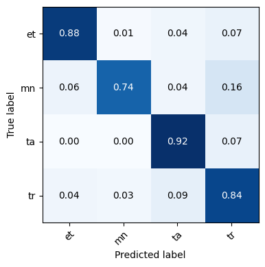

```python
import pandas as pd
from lidbox.util import evaluate_testset_with_model
from lidbox.visualize import draw_confusion_matrix


def display_classification_report(report):
    for m in ("avg_detection_cost", "avg_equal_error_rate", "accuracy"):
        print("{}: {:.3f}".format(m, report[m]))

    lang_metrics = pd.DataFrame.from_dict(
        {k: v for k, v in report.items() if k in lang2target})
    lang_metrics["mean"] = lang_metrics.mean(axis=1)
    display(lang_metrics.T)

    fig, ax = draw_confusion_matrix(report["confusion_matrix"], lang2target)


report = evaluate_testset_with_model(
    model=load_trained_model(),
    test_ds=split2ds["test"].map(lambda x: dict(x, input=x["logmelspec"])).batch(1),
    test_meta=meta[meta["split"]=="test"],
    lang2target=lang2target)

display_classification_report(report)
```

## Using the classifier as a feature extractor

In previous examples we stopped here, but this time we'll make use of the internal representation our neural network has learned. As described in the [x-vector paper](http://danielpovey.com/files/2018_odyssey_xvector_lid.pdf), the language vectors should be extracted from the first fully connected layer, without activations. Lets create a new feature extractor model that uses same inputs as the trained x-vector model, but uses the `segment1` layer as its output layer. We also freeze the model by converting it into a `tf.function`.

```python
from lidbox.util import model2function


model = load_trained_model()
xvec_layer = model.get_layer(name="segment1")
xvec_layer.activation = None
xvec_extractor = model2function(
    tf.keras.Model(inputs=model.inputs, outputs=xvec_layer.output))

print("extractor:", str(xvec_extractor))
```

[output not shown]

[output not shown]

[output not shown]

[output not shown]

[output not shown]

[output not shown]

[output not shown]

[output not shown]

[output not shown]

[output not shown]

[output not shown]

[output not shown]

```
extractor: ConcreteFunction <lambda>(x)
  Args:
    x: float32 Tensor, shape=(None, None, 40)
  Returns:
    float32 Tensor, shape=(None, 512)
```

### Extracting a few embeddings

```python
from lidbox.visualize import plot_embedding_vector


def is_not_copy(x):
    return not x["is_copy"]

def batch_extract_embeddings(x):
    with tf.device("GPU"):
        return dict(x, embedding=xvec_extractor(x["logmelspec"]))


embedding_demo_ds = (split2ds["train"]
                     .filter(is_not_copy)
                     .take(12)
                     .batch(1)
                     .map(batch_extract_embeddings)
                     .unbatch())

for x in embedding_demo_ds.as_numpy_iterator():
    print(x["id"].decode("utf-8"), x["embedding"].shape)
    plot_embedding_vector(x["embedding"], figsize=(10, 0.2))
```

[output not shown]

```
common_voice_mn_18589626 (512,)
```

```
common_voice_ta_19171903 (512,)
```

```
common_voice_et_20800798 (512,)
```

```
common_voice_tr_17348534 (512,)
```

```
common_voice_mn_18603608 (512,)
```

```
common_voice_mn_18593842 (512,)
```

```
common_voice_mn_18596637 (512,)
```

```
common_voice_mn_18909588 (512,)
```

```
common_voice_et_20838416 (512,)
```

```
common_voice_ta_19171901 (512,)
```

```
common_voice_mn_18586690 (512,)
```

```
common_voice_mn_18725186 (512,)
```

## Constructing a language vector extractor pipeline

Let's extend our existing `tf.data.Dataset` feature extraction pipelines by appending a step that extracts language vectors (embeddings) with the trained model. We can add all embeddings into our metadata table, under a column called `embedding` in order to keep everything neatly in one location.

```python
def ds_to_embeddings(ds):
    to_pair = lambda x: (x["id"], x["embedding"])
    ds = (ds
        .batch(1)
        .map(batch_extract_embeddings, num_parallel_calls=TF_AUTOTUNE)
        .unbatch()
        .map(to_pair, num_parallel_calls=TF_AUTOTUNE))

    ids = []
    embeddings = []

    for id, embedding in ds.as_numpy_iterator():
        ids.append(id.decode("utf-8"))
        embeddings.append(embedding.astype(np.float32))

    df = pd.DataFrame.from_dict({"id": ids, "embedding": embeddings})
    return df.set_index("id", drop=True, verify_integrity=True)


embeddings_by_split = (ds_to_embeddings(ds) for ds in split2ds.values())
meta = meta.join(pd.concat(embeddings_by_split, verify_integrity=True), how="outer")
assert not meta.embedding.isna().any(axis=None), "Missing embeddings, some rows contained NaN values"
```

## Preprocessing the language vectors for back-end training

Now, let's extract all embeddings and integer targets into NumPy-data and preprocess them with scikit-learn.

```
training vectors (16728, 512) (16728,)
test vectors (7569, 512) (7569,)
PLDA reduced dimensions from (16728, 512) to (16728, 3)
```

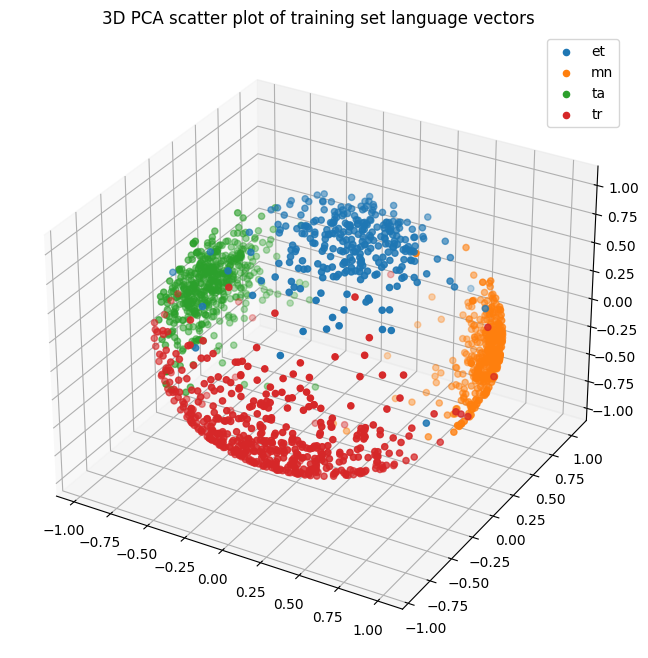

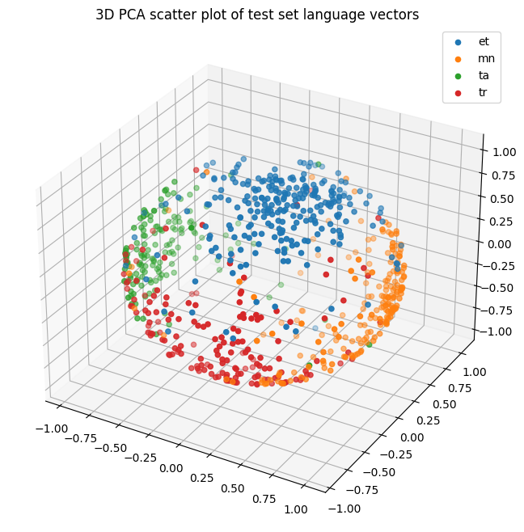

```python
import matplotlib.pyplot as plt
from mpl_toolkits.mplot3d import Axes3D

from sklearn.preprocessing import StandardScaler, normalize
from sklearn.decomposition import PCA
from lidbox.embed.sklearn_utils import PLDA


def embeddings_as_numpy_data(df):
    X = np.stack(df.embedding.values).astype(np.float32)
    y = df.target.to_numpy(dtype=np.int32)
    return X, y


def random_sample(X, y, sample_size_ratio):
    N = X.shape[0]
    sample_size = int(sample_size_ratio*N)
    sample_idx = np_rng.choice(np.arange(N), size=sample_size, replace=False)
    return X[sample_idx], y[sample_idx]


def pca_3d_scatterplot_by_label(data, targets, split_name):
    target2lang = {t: l for l, t in lang2target.items()}

    df = pd.DataFrame.from_dict({
        "x": data[:,0],
        "y": data[:,1],
        "z": data[:,2],
        "lang": [target2lang[t] for t in targets],
    })

    fig = plt.figure(figsize=(8, 8))
    ax = fig.add_subplot(111, projection='3d')

    for lang, g in df.groupby("lang"):
        ax.scatter(g.x, g.y, g.z, label=lang)

    ax.legend()
    ax.set_title("3D PCA scatter plot of {} set language vectors".format(split_name))
    plt.show()


train_X, train_y = embeddings_as_numpy_data(meta[meta["split"]=="train"])
print("training vectors", train_X.shape, train_y.shape)
test_X, test_y = embeddings_as_numpy_data(meta[meta["split"]=="test"])
print("test vectors", test_X.shape, test_y.shape)

# Standardize all vectors using training set statistics
scaler = StandardScaler()
scaler.fit(train_X)
train_X = scaler.transform(train_X)
test_X = scaler.transform(test_X)

# Reduce dimensions
pre_shape = train_X.shape
plda = PLDA()
plda.fit(train_X, train_y)
train_X = plda.transform(train_X)
test_X = plda.transform(test_X)
print("PLDA reduced dimensions from {} to {}".format(pre_shape, train_X.shape))

# L2-normalize vectors to surface of a unit sphere
train_X = normalize(train_X)
test_X = normalize(test_X)

# Map vectors to 3D with PCA and plot scatterplots of 10% random samples
pca = PCA(n_components=3, whiten=False)
pca.fit(train_X)

X, y = random_sample(pca.transform(train_X), train_y, 0.1)
pca_3d_scatterplot_by_label(X, y, "training")

X, y = random_sample(pca.transform(test_X), test_y, 0.1)
pca_3d_scatterplot_by_label(X, y, "test")
```

## Fit classifier on training set vectors and evaluate on test set vectors

Finally, we train a classifier on the training set vectors and predict some language scores on the test set vectors, from which we compute all metrics as before.

```
avg_detection_cost: 0.110
avg_equal_error_rate: 0.096
accuracy: 0.825
```

|  | precision | recall | f1-score | support | equal_error_rate |
| --- | --- | --- | --- | --- | --- |
| et | 0.923465 | 0.884414 | 0.903518 | 2483.00 | 0.071766 |
| mn | 0.918353 | 0.727072 | 0.811594 | 1810.00 | 0.108005 |
| ta | 0.889579 | 0.786935 | 0.835115 | 1638.00 | 0.073343 |
| tr | 0.624513 | 0.880342 | 0.730682 | 1638.00 | 0.131681 |
| mean | 0.838977 | 0.819691 | 0.820227 | 1892.25 | 0.096199 |

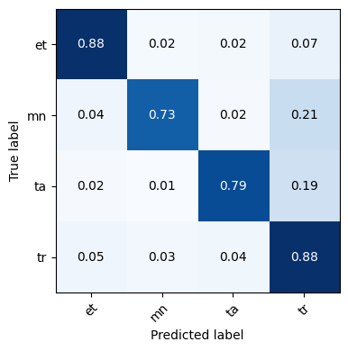

```python
from sklearn.naive_bayes import GaussianNB
from lidbox.util import classification_report


# Fit classifier
clf = GaussianNB()
clf.fit(train_X, train_y)

# Predict scores on test set with classifier and compute metrics
test_pred = clf.predict_log_proba(test_X)
# Clamp -infs to -100
test_pred = np.maximum(-100, test_pred)
report = classification_report(test_y, test_pred, lang2target)
display_classification_report(report)
```

## Conclusions

We were unable to improve our classification results by training a separate back-end classifier on the internal representation of the x-vector neural network. However, this technique can be useful if you have a pre-trained neural network and want to train a classifier on new data.